# Interactions OLS

### **NOTES ON STATISTICS, PROBABILITY and MATHEMATICS**

### Interpreting Interactions OLS:

This entry appeared initially as a CV post [here](http://stats.stackexchange.com/q/185583/67822).

If the interaction happens between a `continuous` and a `discrete` variable it is (if I’m not mistaken) relatively straightforward. The mathematical expression is:

$Y=β_0+β_1X_1+β_2X_2+β_3X_1∗X_2+\epsilon$

So if we take my favorite dataset `mtcars{datasets}` in R, and we carry out the following regression:

```
(fit <- lm(mpg ~ wt * am, mtcars))

Call:
lm(formula = mpg ~ wt * am, data = mtcars)

Coefficients:
(Intercept)           wt           am        wt:am
     31.416       -3.786       14.878       -5.298
```

But when it is two `continuous` variables that are interacting, are we really creating an infinite number of slopes? For example, take the explanatory variables `wt` (weight) and `hp` (horsepower) and the regressand `mpg` (miles per gallon):

```
(fit <- lm(mpg ~ wt * hp, mtcars))

Call:
lm(formula = mpg ~ wt * hp, data = mtcars)

Coefficients:
(Intercept)           wt           hp        wt:hp
   49.80842     -8.21662     -0.12010      0.02785
```

*How do we read the output?*

**SOLUTION:**

We can “prove” how these coefficients “work” by simply taking the first values of `mpg`, `wt` and `hp`, which happen to be for the glamorous Mazda RX4:

[figure not shown]

[credit here](http://www.classicandperformancecar.com)

These are:

```
          mpg cyl disp  hp drat   wt  qsec vs am gear carb
Mazda RX4  21   6  160 110  3.9 2.62 16.46  0  1    4    4
```

And simply run `predict(fit)[1] Mazda RX4`, which returns a $\hat y$ value of $23.09547$. No matter what, I have to rearrange the coefficient to get this number - all possible permutations if necessary! No just kidding. Here it is:

`coef(fit)[1] + (coef(fit)[2] * mtcars$wt[1]) + (coef(fit)[3] * mtcars$hp[1]) + (coef(fit)[4] * mtcars$wt[1] * mtcars$hp[1])` $= 23.09547$.

The math expression is:

$\small \hat Y=\hat β_0 (=1^{st}\,\text{coef})\,+\,\hatβ_1 (=2^{nd}\,\text{coef})\,*wt \,+\, \hatβ_2 (=3^{rd}\,\text{coef})\,*hp \,+\, [\hatβ_3(=4^{th}\,\text{coef})\, *wt\,∗\,hp]$

So, as pointed out in the answers, there is only one intercept (the first coefficient), but there are two *“private”* slopes: one for each explanatory variable, *plus* one *“shared”* slope. This shared slope allows obtaining uncountably infinite slopes if we “zip” through $\mathbb{R}$ for all the theoretically possible realizations of one of the variables, and at any point we combine ($+$) the *“shared”* coefficient *times* the remaining random variable (e.g. for `hp = 100`, it would be `0.02785 * 100 * wt`) with its *“private*” slope (`-8.21662 * wt`). I wonder if I can call it a *convolution*…

We can also see that this is the right interpretation running:

```
y <- coef(fit)[1] + (coef(fit)[2] * mtcars$wt[1]) + (coef(fit)[3] * mtcars$hp[1]) + (coef(fit)[4] * mtcars$wt[1] * mtcars$hp[1])
identical(as.numeric(predict(fit)[1]), as.numeric(y)) TRUE
```

Having rediscovered the wheel we see that the “shared” coefficient is positive (0.02785), leaving one loose end, now, which is the explanation as to why the weight of the vehicle as a predictor for “gas-guzzliness” is buffered for higher horse-powered cars… We can see this effect (thank you @Glen_b for the tip) with the $3\,D$ plot of the predicted values in this regression model, which conforms to the following *parabolic hyperboloid*:

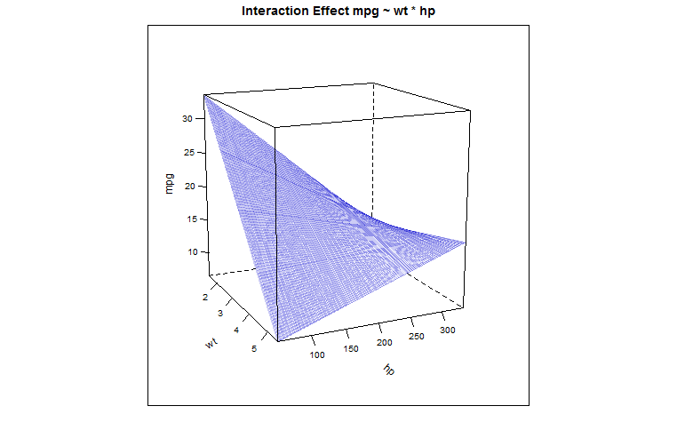

[Home Page](http://rinterested.github.io/statistics/index.html)

**NOTE: These are tentative notes on different topics for personal use - expect mistakes and misunderstandings.**